# Zillow EDA Tax Prices

#### This is my first kaggle kernel.

#### It attempts to follow along from Philipp Spachtholz’s Exploratory Analysis - Zillow

#### using data.tables when possible instead of dplyr.

#### Goal is to ultimately use the tax information + lat lon to do some cool mapping and learn leaftlet

Loads packages

```
[1] "C:/Users/tianh/Dropbox/2017/kaggle/zillow/output"
```

[output not shown]

Makes our data more user friendly by renaming colnames

### Explores transactions by timeframe.

Pretty boring so far, no real insights.

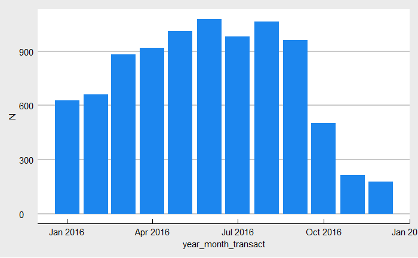

```r
df_transactions[, date_of_transact:= as.Date(date_of_transact)]
df_transactions[, month_of_transact:= month(date_of_transact)]
df_transactions[, year_of_transact:= year(date_of_transact)]
df_transactions[, year_month_transact:= make_date(year=year(date_of_transact),month=month(date_of_transact))]
#need to add unique() here
#transacts_per_year <- df_transactions[, N := uniqueN(id_parcel), by = year_month_transact]
transacts_per_year <- df_transactions[, .N, by = year_month_transact]
transacts_per_day <- df_transactions[, .N, by = date_of_transact]
ggplot(transacts_per_year,aes(x=year_month_transact,y=N)) + geom_bar(stat="identity", fill="dodgerblue2")
```

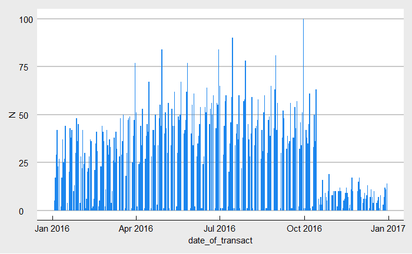

```r
ggplot(transacts_per_day,aes(x=date_of_transact,y=N)) + geom_bar(stat="identity", fill="dodgerblue2")
```

Plots some exploratory analysis by tax data

First up a frequency plot by the different tax values for land and structure

```r
long_tax <- melt(df_properties,
                 id.vars = c("id_parcel"),
                 measure.vars = c("tax_totalvalue", "tax_landvalue", "tax_structurevalue"),
                 variable.name = "tax_type",
                 value.name = "tax_value")
str(long_tax)
```

```
Classes data.table and 'data.frame':  27243 obs. of  3 variables:
 $ id_parcel: int  17134926 17275763 10772282 10863512 10863950 10901050 11060445 11085589 11155347 11161277 ...
 $ tax_type : Factor w/ 3 levels "tax_totalvalue",..: 1 1 1 1 1 1 1 1 1 1 ...
 $ tax_value: num  571086 256000 391643 226114 1050000 ...
 - attr(*, ".internal.selfref")=<externalptr>
```

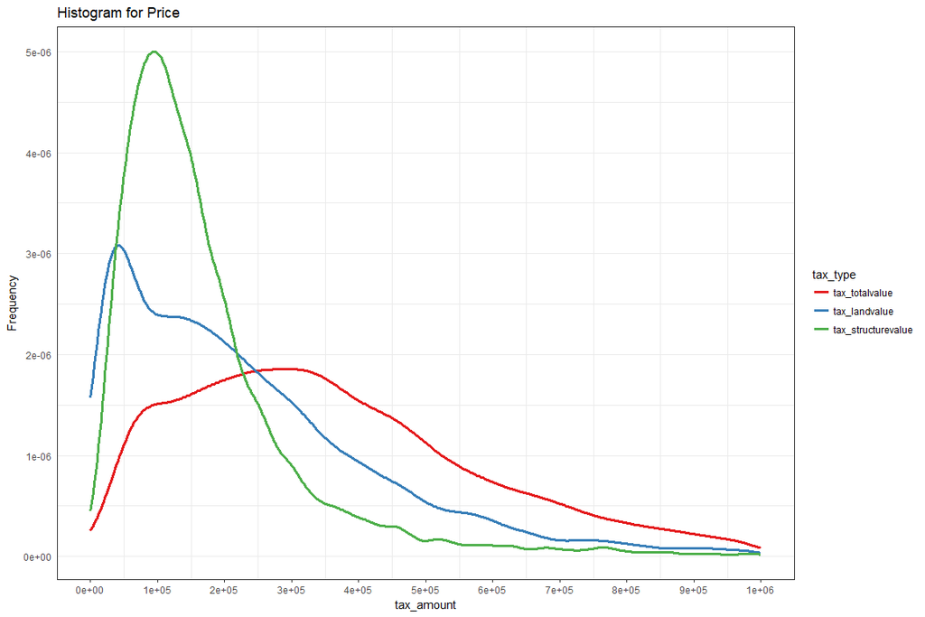

```r
col_pal <- "Set1"
ggplot(long_tax, aes(x=tax_value, colour = tax_type)) +
  geom_line(stat="density", size=1.2) +
  theme_bw()+
  scale_fill_brewer(palette=col_pal)+
  scale_color_brewer(palette=col_pal) +
  #stat_bin(binwidth = 50000) +
  labs(title="Histogram for Price") +
  scale_x_continuous(name = "tax_amount", breaks = 10^5*(0:12), limits = c(0, 10^6)) +
  scale_y_continuous(name = "Frequency")
```

Linear buckets arn’t cutting it

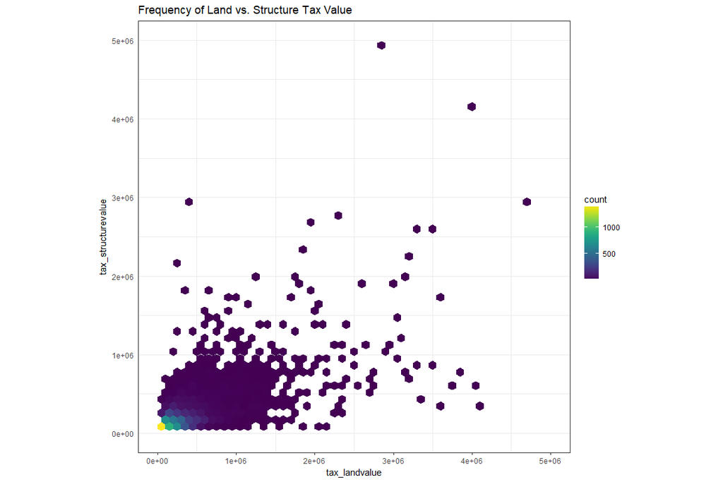

```r
ggplot(df_properties, aes(tax_landvalue, tax_structurevalue))+
    geom_hex(bins = 50) + coord_fixed() +
    scale_fill_viridis() +
    theme_bw() +
  ggtitle("Frequency of Land vs. Structure Tax Value") +
  theme(legend.position="right") +
  xlim(0, 5*10^6) +
  ylim(0, 5*10^6)
```

```r
NA
```

Couldn’t get viridis palette to work on a log scale hexbin so manually hacked my own using their color pallete.

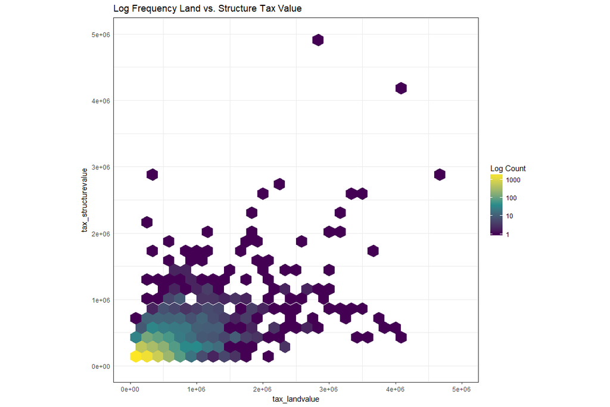

```r
ggplot(df_properties, aes(tax_landvalue, tax_structurevalue))+
    geom_hex(bins = 30) + coord_fixed() +
    scale_fill_gradientn(name = "Log Count", trans = "log10",
                        breaks = 10^(0:6), colors = c("#440154","#21908d","#fde725")) +
    theme_bw() +
  ggtitle("Log Frequency Land vs. Structure Tax Value") +
  theme(legend.position="right") +
  xlim(0, 5*10^6) +
  ylim(0, 5*10^6)
```

Using coordinate data we have a cool visual heatmap of where all our properties are in LA

[figure not shown]

```r
df_properties[,lat:= latitude/1e06]
df_properties[,lon:= longitude/1e06]
ggplot(df_properties, aes(lat, lon))+
    geom_hex(bins = 200) + coord_fixed() +
    scale_fill_gradientn(name = "Number of Properties",
                        breaks = 250*(0:8), colors = c("#440154","#21908d","#fde725")) +
    theme_bw() +
  ggtitle("Log Frequency Land vs. Structure Tax Value") +
  theme(legend.position="right")
```

```r
lat <- range(df_properties$latitude/1e06,na.rm=T)
lon <- range(df_properties$longitude/1e06,na.rm=T)
tmp <- df_properties %>%
  select(id_parcel,longitude,latitude, tax_totalvalue) %>%
  mutate(lon=longitude/1e6,lat=latitude/1e6, logtax = log10(tax_totalvalue)) %>%
  select(id_parcel,lat,lon, logtax) %>%
  left_join(df_transactions,by="id_parcel")
```

To be continued

[figure not shown]

```r
library(ggmap)
mapa <- get_map(location = c(lon = -118.255, lat = 34.049), zoom = 9, maptype = "hybrid")
ggmap(mapa) +
  geom_point(data = df_properties, aes(x = lon, y = lat, color = tax_totalvalue, alpha = 0.8))+
  scale_colour_gradient2(high = "darkred", mid = "yellow", low = "white", midpoint = median(df_properties$tax_totalvalue, na.rm = TRUE)/2,
  space = "Lab", na.value = "grey50", guide = "colourbar") +
  scale_fill_viridis()
```

```r
median(df_properties$tax_totalvalue, na.rm = TRUE)
```

```
[1] 347764.5
```

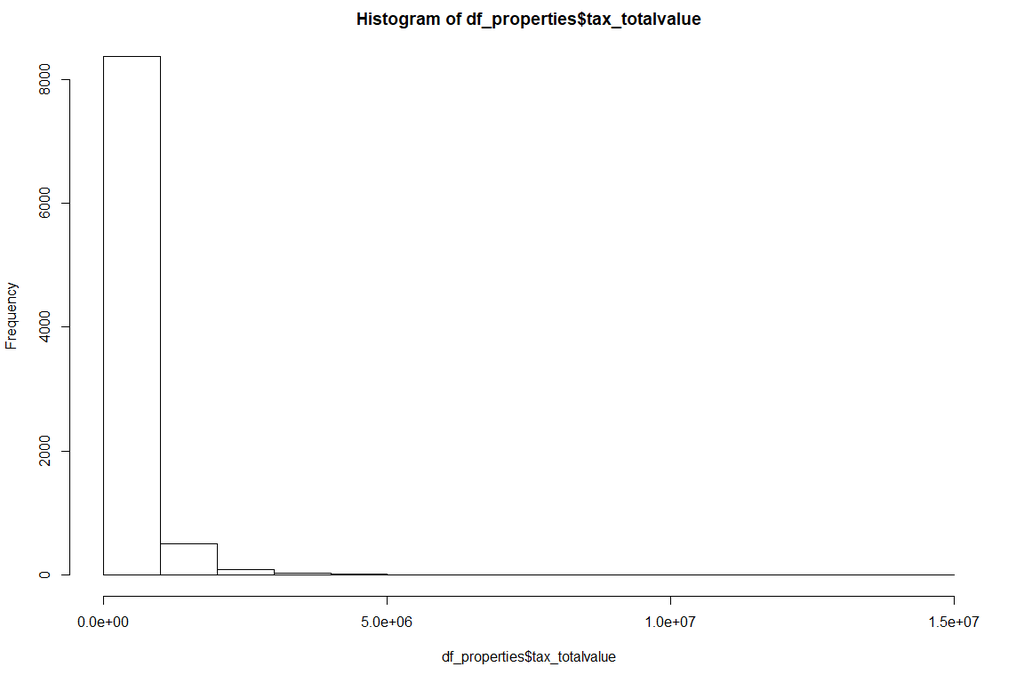

```r
hist(df_properties$tax_totalvalue)
```